# SRT411A0

Jacob Marsillo

January 30, 2017

Github Username= Jmarsillo

## Assignment Intro

The purpose of this assignment is to create code using RStudio to accomplish various tasks from calculation to plotting graphs and use Rmarkdown and knitr packages to format them into an easy to follow document that will be posted on Github.

## ToDo 1:

Calculate what perentage of your life has been spent at Seneca.

```r
((2017-2015)/(2017-1994))*100
```

```
## [1] 8.695652
```

## ToDo 2:

Repeat the previous ToDo, but with several steps in between. You can give the variables any name you want, but the name has to start with a letter.

```r
a = 2017-2015 #years at Seneca
b = 2017-1994 #years since birth
(a/b)*100
```

```
## [1] 8.695652
```

## ToDo 3:

Compute the sum of 4, 5, 8 and 11 by first com-bining them into a vector and then using the function sum.

```r
b =c(4,5,8,11)
sum(b)
```

```
## [1] 28
```

## ToDo 4:

Plot 100 normal random numbers.

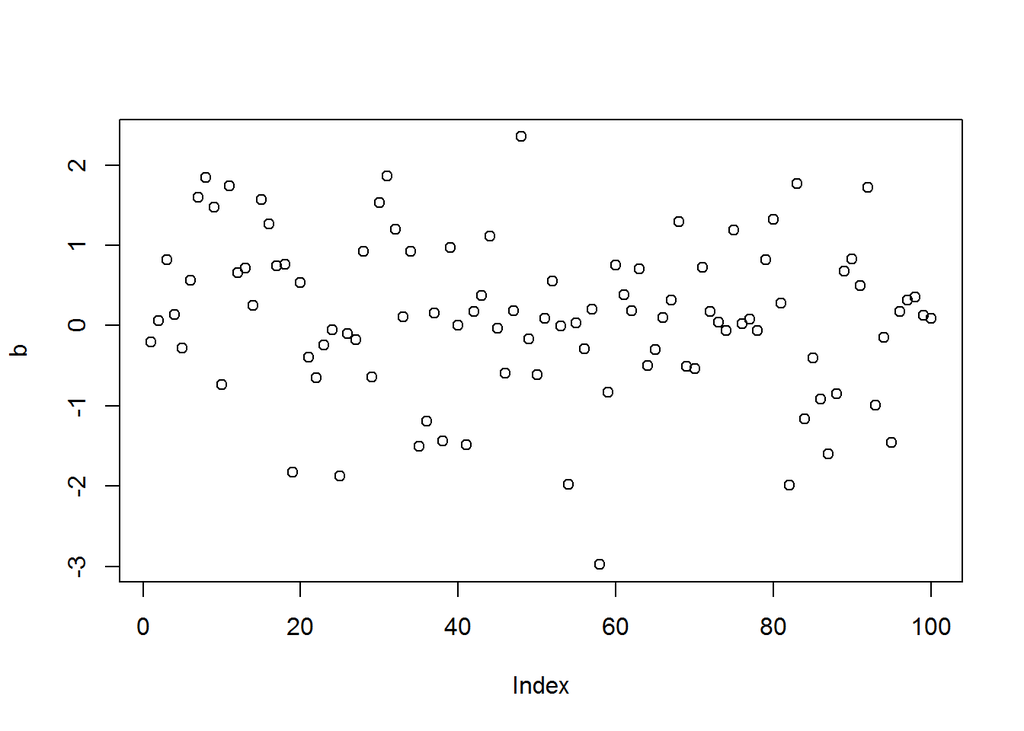

```r
b <- rnorm(100)
plot(b)
```

## ToDo 5:

Find help for the sqrt function

```r
help(sqrt)
```

## ToDo 6:

Make a file called firstscript.R containing Rcode that generates 100 random numbers and plots them, and run this script several times.

[Script File](https://github.com/jmarsillo/SRT411-Assignment-0/blob/master/firstscript.R)

Contents:

```r
b <- rnorm(100)
plot(b)
```

Code to run script 3 times:

```r
source("firstscript.R")
```

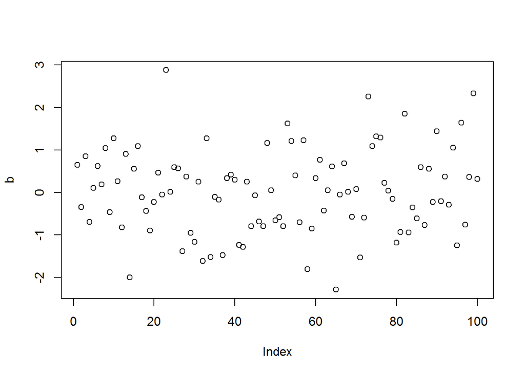

```r
source("firstscript.R")
```

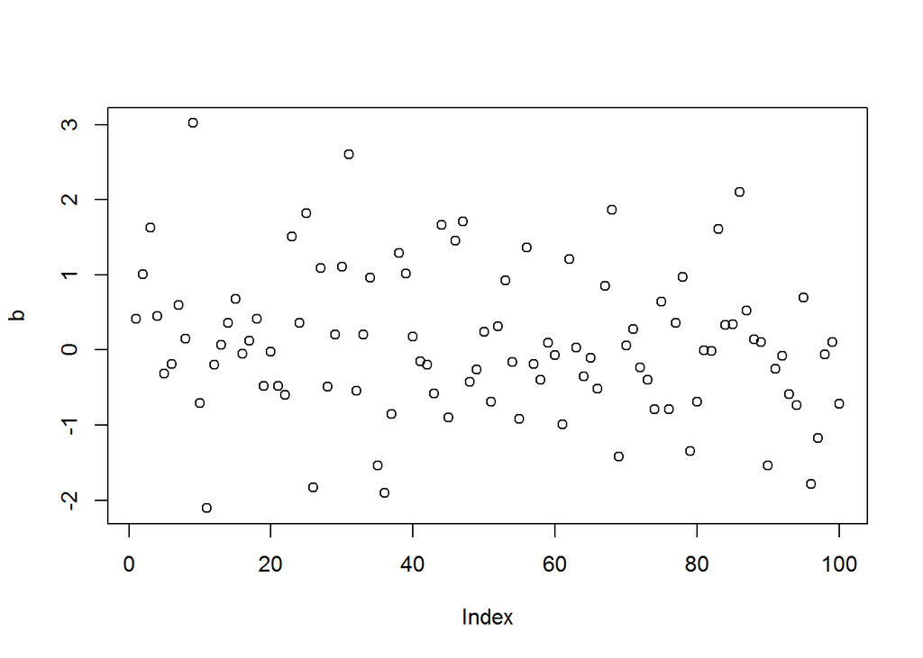

```r
source("firstscript.R")
```

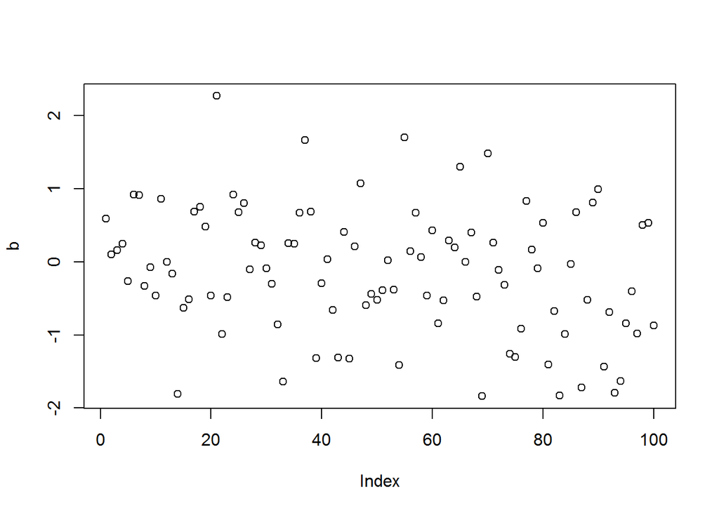

## ToDo 7:

Put the numbers 31 to 60 in a vector named P and in a matrix with 6 rows and 5 columns named Q. Tip: use the function seq. Look at the different ways scalars, vectors and matrices are denoted in the workspace window.

```r
P <- seq(from=31, to=60)
Q <- matrix(P, nrow=6, ncol=5)
P
```

```
##  [1] 31 32 33 34 35 36 37 38 39 40 41 42 43 44 45 46 47 48 49 50 51 52 53
## [24] 54 55 56 57 58 59 60
```

```r
Q
```

```
##      [,1] [,2] [,3] [,4] [,5]
## [1,]   31   37   43   49   55
## [2,]   32   38   44   50   56
## [3,]   33   39   45   51   57
## [4,]   34   40   46   52   58
## [5,]   35   41   47   53   59
## [6,]   36   42   48   54   60
```

## ToDo 8:

Make a script file which constructs three random normal vectors of length 100. Call these vectors x1, x2 and x3. Make a data frame called t with three columns (called a, b and c) containing respectively x1, x1+x2 and x1+x2+x3. Call the following functions for this data frame: plot(t) and sd(t). Can you understand the results? Rerun this script a few times.

[Script File](https://github.com/jmarsillo/SRT411-Assignment-0/blob/master/secondscript.R)

Contents:

```r
x1<-rnorm(100)
x2<-rnorm(100)
x3<-rnorm(100)
t<- data.frame(a=x1, b=x1+x2, c=x1+x2+x3)
```

Code to run scrit and plot (t) and sd(t)

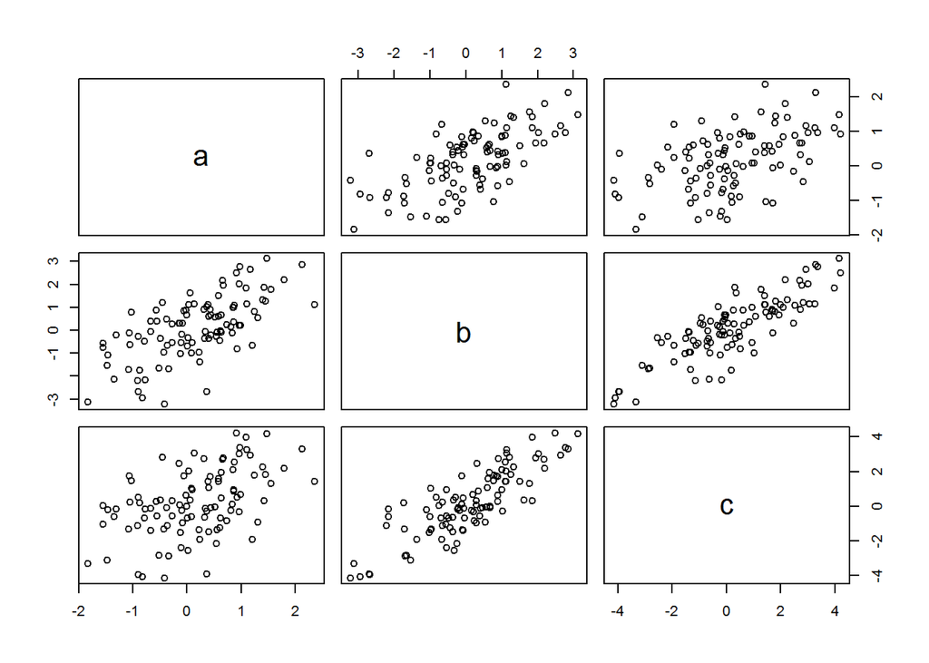

```r
source("secondscript.R")
plot(t)
```

```r
sapply(t, sd)
```

```
##         a         b         c
## 0.8703266 1.3449802 1.9025492
```

Repeat above code to run multiple times. I had an issue plotting sd it seems that it doesn’t properly work with the data.frame function.

## ToDo 9:

Add these lines to the script file of the previous section. Try to find out, either by experiment- ing or by using the help, what the meaning is of rgb, the last argument of rgb, lwd, pch, cex. To add: plot(t$a, type="l", ylim=range(t), lwd=3, col=rgb(0.9,0,0,0.9)) lines(t$b, type=“s”, lwd=2, col=rgb(0,0.9,0,0.9)) points(t$c, pch=4, cex=1, col=rgb(0,0,1,0.9))

[Modified Script File](https://github.com/jmarsillo/SRT411-Assignment-0/blob/master/Modifiedsecondscript.R)

To run the script:

```r
source("Modifiedsecondscript.R")
```

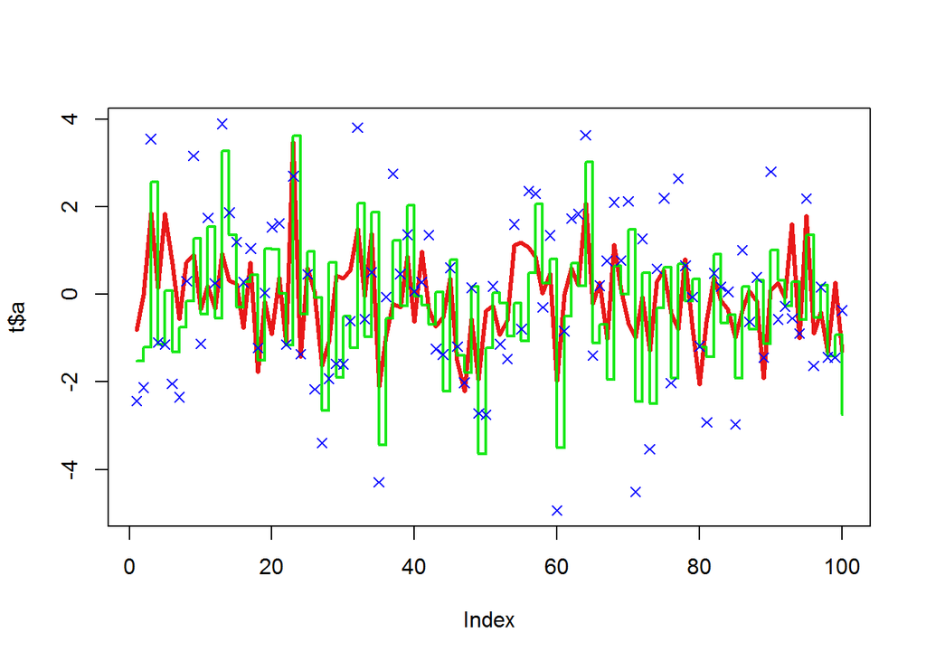

#### Meaning of Given Parameters

lwd signifies the line width in comparison the the default, which is 1.

pch signifies which symbol is going to be used for the points on the plot.

cex signifies the scaling for the plot text and symbols (i.e 2 is 200%, 1 is default, 0.5 is 50%)

rgb signifies the red, green, blue colour of the points with the final value being the opacity of the colour.

## ToDo 10:

Make a file called tst1.txt in Notepad from the example in Figure 4 and store it in your working directory. Write a script to read it, to multiply the column called g by 5 and to store it as tst2.txt.

tst1.txt

todo10script.R

Contents of the script:

```r
x <-data.frame(read.table(file="tst1.txt", header = TRUE));
x$g = x$g*5
write.table(x, file="tst2.txt", row.names = FALSE)
```

Use the following code to run the script that will create tst2.txt:

```r
source("todo10script.R")
```

This is the result of running the script:

tst2.txt

## ToDo 11:

Compute the mean of the square root of a vec- tor of 100 random numbers. What happens?

```r
x <- rnorm(100)
mean(sqrt(x))
```

```
## Warning in sqrt(x): NaNs produced
```

```
## [1] NaN
```

When trying to sqrt the vector imaginary numbers are produced. The output says “warning NaNs produced.” This means “Not a Number”. It is not possible to find the mean of imaginary numbers therefore, when the mean function runs, it also returns “NaN”.

## ToDo 12:

Make a graph with on the x-axis: today, Sinterklaas 2017 and your next birthday and on the y-axis the number of presents you expect on each of these days. Tip: make two vectors first.

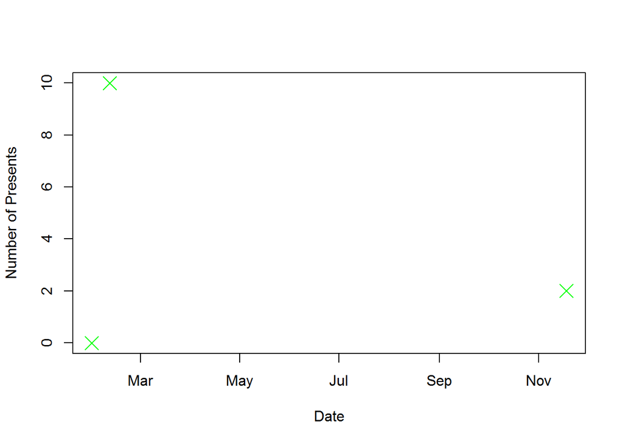

```r
#Vector for the dates.
x <- strptime(c("20170130", "20171118", "20170210"), format ="%Y%m%d")
#Vector for number of presents on each day: 0 today, 2 on Sinterklaas, and 10 on my birthday.
y <- c(0,2,10)
plot(x,y, type="p", pch=4, cex=2, xlab="Date", ylab="Number of Presents", col=rgb(0,1,0,1))
```

## ToDo 13:

Make a vector from 1 to 100. Make a for-loop which runs through the whole vector. Multiply the elements which are smaller than 5 and larger than 90 with 10 and the other elements with 0.1.

```r
x <- seq(from=1, to=100, by=1)
y <- c()
for(i in 1:100)
{
  if (x[i]<5)
  {
    y[i]=x[i]*10;
  }
  else if (x[i]>90)
  {
    y[i]=x[i]*10;
  }
  else
  {
    y[i]=x[i]*0.1;
  }
}
y
```

```
##   [1]   10.0   20.0   30.0   40.0    0.5    0.6    0.7    0.8    0.9    1.0
##  [11]    1.1    1.2    1.3    1.4    1.5    1.6    1.7    1.8    1.9    2.0
##  [21]    2.1    2.2    2.3    2.4    2.5    2.6    2.7    2.8    2.9    3.0
##  [31]    3.1    3.2    3.3    3.4    3.5    3.6    3.7    3.8    3.9    4.0
##  [41]    4.1    4.2    4.3    4.4    4.5    4.6    4.7    4.8    4.9    5.0
##  [51]    5.1    5.2    5.3    5.4    5.5    5.6    5.7    5.8    5.9    6.0
##  [61]    6.1    6.2    6.3    6.4    6.5    6.6    6.7    6.8    6.9    7.0
##  [71]    7.1    7.2    7.3    7.4    7.5    7.6    7.7    7.8    7.9    8.0
##  [81]    8.1    8.2    8.3    8.4    8.5    8.6    8.7    8.8    8.9    9.0
##  [91]  910.0  920.0  930.0  940.0  950.0  960.0  970.0  980.0  990.0 1000.0
```

## ToDo 14:

Write a function for the previous ToDo, so that you can feed it any vector you like (as argument). Use a for-loop in the function to do the computation with each element. Use the standard R function length in the specification of the counter.

```r
v=1:100
td14func = function(arg1)
{
  l = length(arg1)
  for(i in 1:l)
  {
    if (arg1[i] < 5 | arg1[i] > 90)
    {
      arg1[i] = arg1[i] * 10
    }
    else
    {
      arg1[i] = arg1[i] * 0.1
    }
  }
  return (arg1)
}
td14func(arg1=v)
```

```
##   [1]   10.0   20.0   30.0   40.0    0.5    0.6    0.7    0.8    0.9    1.0
##  [11]    1.1    1.2    1.3    1.4    1.5    1.6    1.7    1.8    1.9    2.0
##  [21]    2.1    2.2    2.3    2.4    2.5    2.6    2.7    2.8    2.9    3.0
##  [31]    3.1    3.2    3.3    3.4    3.5    3.6    3.7    3.8    3.9    4.0
##  [41]    4.1    4.2    4.3    4.4    4.5    4.6    4.7    4.8    4.9    5.0
##  [51]    5.1    5.2    5.3    5.4    5.5    5.6    5.7    5.8    5.9    6.0
##  [61]    6.1    6.2    6.3    6.4    6.5    6.6    6.7    6.8    6.9    7.0
##  [71]    7.1    7.2    7.3    7.4    7.5    7.6    7.7    7.8    7.9    8.0
##  [81]    8.1    8.2    8.3    8.4    8.5    8.6    8.7    8.8    8.9    9.0
##  [91]  910.0  920.0  930.0  940.0  950.0  960.0  970.0  980.0  990.0 1000.0
```

## ToDo 15:

Actually, people often use more for-loops than necessary. The ToDo above can be done more easily and quickly without a for-loop but with regular vectorcomputations.Accomplish ToDo 14 without the use of for-loops.

```r
v=c(1:100)
ifelse(v < 5 | v > 90, v * 10, v * 0.1)
```

```
##   [1]   10.0   20.0   30.0   40.0    0.5    0.6    0.7    0.8    0.9    1.0
##  [11]    1.1    1.2    1.3    1.4    1.5    1.6    1.7    1.8    1.9    2.0
##  [21]    2.1    2.2    2.3    2.4    2.5    2.6    2.7    2.8    2.9    3.0
##  [31]    3.1    3.2    3.3    3.4    3.5    3.6    3.7    3.8    3.9    4.0
##  [41]    4.1    4.2    4.3    4.4    4.5    4.6    4.7    4.8    4.9    5.0
##  [51]    5.1    5.2    5.3    5.4    5.5    5.6    5.7    5.8    5.9    6.0
##  [61]    6.1    6.2    6.3    6.4    6.5    6.6    6.7    6.8    6.9    7.0
##  [71]    7.1    7.2    7.3    7.4    7.5    7.6    7.7    7.8    7.9    8.0
##  [81]    8.1    8.2    8.3    8.4    8.5    8.6    8.7    8.8    8.9    9.0
##  [91]  910.0  920.0  930.0  940.0  950.0  960.0  970.0  980.0  990.0 1000.0
```